# CO543 - Image Processing

# E/17/219

# Lab 3

```python
#importing libraries
import numpy as np
import cv2 as cv
import matplotlib.pyplot as plt

# #imporot the patch for the google colab
from google.colab.patches import cv2_imshow
```

```python
#specifying the folder in the google drive
folder_name = '/content/drive/MyDrive/CO543-Image Processing/Lab3/'
```

```python
#load the images for image processing and testing
img = cv.imread(folder_name + 'Sample image.jpg',0)
cameraman = cv.imread(folder_name + 'cameraman.png',0)

img[0:10,0:10],cameraman[0:10,0:10]
```

```
(array([[ 83,  81,  69,  91,   0,  87,  75,  84, 100,  73],
        [ 69,  73, 114,  80,  96,  90,  83, 100,  90,   5],
        [102, 255, 201, 167, 154, 155, 183, 155, 255, 148],
        [  0,  76, 223, 147, 156, 169, 160, 255, 168, 164],
        [ 92,  76, 220, 161, 174,   4,   0, 156, 255, 150],
        [ 89,  86, 209, 157, 160, 174, 157, 161, 151, 147],
        [103,   0, 240, 166,  13, 172, 251,   0, 168, 171],
        [ 78,  84, 217, 155, 171, 171, 164, 255, 255, 160],
        [ 95,  77, 218, 156, 155, 179, 169, 160, 159, 141],
        [  0, 100, 217, 166, 182, 148, 164, 166, 165, 171]], dtype=uint8),
 array([[166, 160, 146, 158, 149, 157, 158, 153, 154, 157],
        [146, 157, 157, 153, 160, 158, 159, 158, 163, 156],
        [143, 150, 161, 163, 149, 155, 151, 149, 154, 156],
        [153, 149, 157, 155, 164, 145, 156, 155, 158, 151],
        [143, 157, 155, 145, 153, 147, 148, 153, 155, 151],
        [159, 153, 160, 150, 157, 150, 158, 166, 156, 152],
        [155, 158, 150, 150, 160, 165, 153, 158, 162, 153],
        [145, 158, 152, 158, 162, 163, 157, 153, 162, 158],
        [156, 157, 158, 160, 154, 159, 154, 156, 159, 163],
        [150, 156, 154, 146, 147, 157, 148, 155, 152, 153]], dtype=uint8))
```

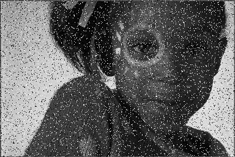

```python
#display the sample images
cv2_imshow(img)
cv2_imshow(cameraman)
```

Below Function is used for comparing the input and the output images.

```python
def horizontal_show(imgs, title,interpolation = cv.INTER_CUBIC):
    #print the title
    print(title)

    #get the mininmum height
    min_height = min(img.shape[0] for img in imgs)

    #resizie each image
    images = [cv.resize(img,(int(img.shape[1] * min_height / img.shape[0]),min_height), interpolation= interpolation) for img in imgs]

    #show images
    cv2_imshow(cv.hconcat(images))
```

## 1. Apply Mean filtering with mask size 3x3 and 5x5

```python
def mean(img,kernal_size):
  '''
    This funcation applies the mean filter to any given image and returns the
    resulting image.

    Note : kernal size is the width of the kernal.
    ex : 3x3 kernal has 9 squares.
  '''

  #getting the dividing value in order to get the average value
  dividing_value = kernal_size**2

  #array iterating values
  col_start = int(kernal_size/2)
  col_end = len(img[0])-int(kernal_size/2)
  row_start = int(kernal_size/2)
  row_end = len(img) - int(kernal_size/2)

  #output array
  output = []

  #getting the values assgined
  for i in range(row_start,row_end):

    #this list stores values related to one list
    row = []

    #getting values related to one list
    for j in range(col_start,col_end):

      #getting the kernal values
      kernal = img[i-int(kernal_size/2):i+int(kernal_size/2)+1,j-int(kernal_size/2):j+int(kernal_size/2)+1]

      #get the average of the kernal
      value = np.sum(kernal)/dividing_value

      #storing the average
      row.append(value)

    #get each row
    output.append(row)

  return np.array(output,dtype=np.uint8)
```

```
Original image vs 3x3 Mean Filtered image
```

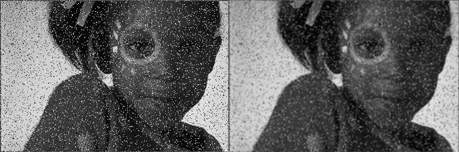

```
Original image vs 5x5 Mean Filtered image
```

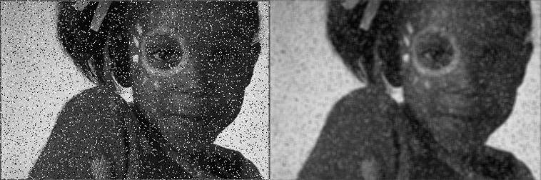

```python
#displaying the results
mean_filtered_img3 = mean(img,3)
mean_filtered_img5 = mean(img,5)
horizontal_show([img,mean_filtered_img3],"Original image vs 3x3 Mean Filtered image")
horizontal_show([img,mean_filtered_img5],"Original image vs 5x5 Mean Filtered image")
```

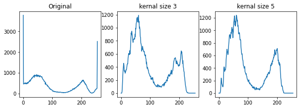

```python
#dispalying histograms of each images
hist_1 = cv.calcHist([img],[0],None,[256],[0,256])
hist_2 = cv.calcHist([mean_filtered_img3],[0],None,[256],[0,256])
hist_3 = cv.calcHist([mean_filtered_img5],[0],None,[256],[0,256])

fig = plt.figure(figsize=(10, 7))
fig.add_subplot(2, 3, 4)
plt.title("Original")
plt.plot(hist_1)
fig.add_subplot(2, 3, 5)
plt.title("kernal size 3")
plt.plot(hist_2)
fig.add_subplot(2, 3, 6)
plt.title("kernal size 5")
plt.plot(hist_3)
```

### Comments

By looking at these histograms it can be said that high frequency componants are removed and the images has got smoother with a little bit of noise.

## 2. Apply Highpass filtering with mask size 3x3 and 5x5

```python
def ApplyFilter(img,mask,kernal_size=3):
  '''
    This funcation applies the various filters to any given image and returns the
    resulting image. The filter is based on the mask variable.

    ex : for low pass 3x3 filter mask = [[-1,-1,-1],[-1,8,-1],[-1,-1,-1]]

    Note : kernal size is the width of the kernal.
    ex : 3x3 kernal has 9 squares.
  '''

  #array iterating values
  col_start = int(kernal_size/2)
  col_end = len(img[0])-int(kernal_size/2)
  row_start = int(kernal_size/2)
  row_end = len(img) - int(kernal_size/2)

  #output array
  output = []

  #getting the values assgined
  for i in range(row_start,row_end):

    #this list stores values related to one list
    row = []

    #getting values related to one list
    for j in range(col_start,col_end):

      #getting the kernal values
      kernal = img[i-int(kernal_size/2):i+int(kernal_size/2)+1,j-int(kernal_size/2):j+int(kernal_size/2)+1]

      #convert the kernal to a numpy array
      kernal = np.array(kernal)

      #matrix multiplication
      mul = np.multiply(mask,kernal)

      #get the average of the kernal
      value = np.sum(mul)

      #storing the average
      if value<=0:
        row.append(0)
      elif value>=255:
        row.append(255)
      else:
        row.append(value)

    #get each row
    output.append(row)

  return np.array(output,dtype=np.int64)
```

Displaying the results for 3x3 mask output

[figure not shown]

```python
high_pass_mask_3 = [[-1,-1,-1],[-1,8,-1],[-1,-1,-1]]
high_pass_mask_3 = np.array(high_pass_mask_3)

#displaying the results for output 3x3
high_pass_kernal_3 = ApplyFilter(cameraman,high_pass_mask_3,kernal_size=3)
cv2_imshow(cameraman)
cv2_imshow(high_pass_kernal_3)
```

Displaying the results for 5x5 mask output

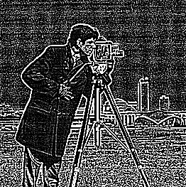

```python
high_pass_mask_5 = [[-1,-1,-1,-1,-1],[-1,-1,-1,-1,-1],[-1,-1,24,-1,-1],[-1,-1,-1,-1,-1],[-1,-1,-1,-1,-1]]
high_pass_mask_5 = np.array(high_pass_mask_5)

#displaying the results for output 5x5
high_pass_kernal_5 = ApplyFilter(cameraman,high_pass_mask_5,kernal_size=5)
cv2_imshow(cameraman)
cv2_imshow(high_pass_kernal_5)
```

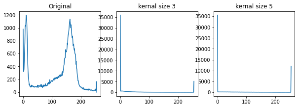

```python
#dispalying histograms of each images
hist_1 = cv.calcHist([cameraman],[0],None,[256],[0,256])
hist_2 = cv.calcHist([np.array(high_pass_kernal_3,dtype=np.uint8)],[0],None,[256],[0,256])
hist_3 = cv.calcHist([np.array(high_pass_kernal_5,dtype=np.uint8)],[0],None,[256],[0,256])

fig = plt.figure(figsize=(10, 7))
fig.add_subplot(2, 3, 4)
plt.title("Original")
plt.plot(hist_1)
fig.add_subplot(2, 3, 5)
plt.title("kernal size 3")
plt.plot(hist_2)
fig.add_subplot(2, 3, 6)
plt.title("kernal size 5")
plt.plot(hist_3)
```

### Comments

By looking at these histograms it can be said that medium intensity levels are removed and only 0 and 255 intensity levels have frequency. As a result of this , image has gotten more and more sharper

## 3. Apply lowpass filtering with mask size 3x3 and 5x5

Displaying the results for 3x3 mask output

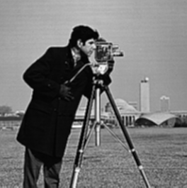

```python
low_pass_mask_3 = np.ones([3,3])/9

#displaying the results for output 3x3
low_pass_kernal_3 = ApplyFilter(cameraman,low_pass_mask_3,kernal_size=3)
cv2_imshow(cameraman)
cv2_imshow(low_pass_kernal_3)
```

Displaying the results for 5x5 mask output

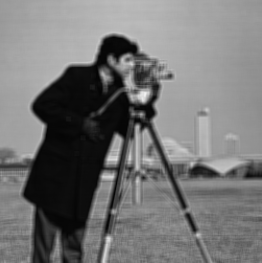

```python
low_pass_mask_5 = np.ones([5,5])/25

#displaying the results for output 5x5
low_pass_kernal_5 = ApplyFilter(cameraman,low_pass_mask_5,kernal_size=5)
cv2_imshow(cameraman)
cv2_imshow(low_pass_kernal_5)
```

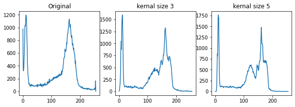

```python
#dispalying histograms of each images
hist_1 = cv.calcHist([cameraman],[0],None,[256],[0,256])
hist_2 = cv.calcHist([np.array(low_pass_kernal_3,dtype=np.uint8)],[0],None,[256],[0,256])
hist_3 = cv.calcHist([np.array(low_pass_kernal_5,dtype=np.uint8)],[0],None,[256],[0,256])

fig = plt.figure(figsize=(10, 7))
fig.add_subplot(2, 3, 4)
plt.title("Original")
plt.plot(hist_1)
fig.add_subplot(2, 3, 5)
plt.title("kernal size 3")
plt.plot(hist_2)
fig.add_subplot(2, 3, 6)
plt.title("kernal size 5")
plt.plot(hist_3)
```

### Comments

By looking at these histograms it can be said that high frequency levels are distributed through out the whole range and as a result , the images has gotten more and more smoother.

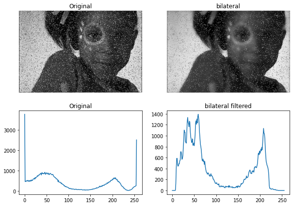

```python
bilateral_image = cv.bilateralFilter(img, 15, 75, 75)

fig = plt.figure(figsize=(10, 7))
fig.add_subplot(2, 2, 1)

plt.imshow(img,cmap="gray")
plt.axis('off')
plt.title("Original")
fig.add_subplot(2, 2, 2)
plt.imshow(bilateral_image,cmap="gray")
plt.axis('off')
plt.title("bilateral")

hist_1 = cv.calcHist([img],[0],None,[256],[0,256])
hist_2 = cv.calcHist([bilateral_image],[0],None,[256],[0,256])

fig.add_subplot(2, 2, 3)
plt.title("Original")
plt.plot(hist_1)
fig.add_subplot(2, 2, 4)
plt.title("bilateral filtered")
plt.plot(hist_2)
```

### Comments

By looking at these histograms it can be said that high frequency levels are distributed through out the whole range and as a result , the images has gotten more and more smoother.

## 5. A Gaussian filter with mask size 5 × 5 appropriate values of σ .

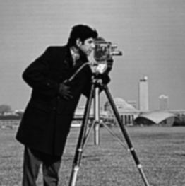

```python
mask_gaussian_filter_5 = 1/273*np.array([
                              [1,4,7,4,1],
                              [4,16,26,16,4],
                              [7,26,41,26,7],
                              [4,16,26,16,4],
                              [1,4,7,4,1]
])

# displaying the results for output 5x5
gaussian_filter_5 = ApplyFilter(cameraman,mask_gaussian_filter_5,kernal_size=5)
cv2_imshow(cameraman)
cv2_imshow(gaussian_filter_5)
```

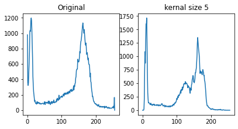

```python
#dispalying histograms of each images
hist_1 = cv.calcHist([cameraman],[0],None,[256],[0,256])
hist_2 = cv.calcHist([np.array(gaussian_filter_5,dtype=np.uint8)],[0],None,[256],[0,256])


fig = plt.figure(figsize=(10, 7))
fig.add_subplot(2, 3, 4)
plt.title("Original")
plt.plot(hist_1)
fig.add_subplot(2, 3, 5)
plt.title("kernal size 5")
plt.plot(hist_2)
```

## 6. A laplacian filter with mask size 5 × 5 appropriate values of σ .

[figure not shown]

```python
mask_laplacian_filter_5 = np.array([
                              [0,0,-1,0,0],
                              [0,-1,-2,-1,0],
                              [-1,-2,17,-2,-1],
                              [0,-1,-2,-1,0],
                              [0,0,-1,0,0]
])

# displaying the results for output 5x5
laplacian_filter_5 = ApplyFilter(cameraman,mask_laplacian_filter_5,kernal_size=5)
cv2_imshow(cameraman)
cv2_imshow(laplacian_filter_5)
```

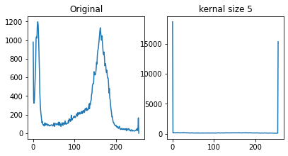

```python
#dispalying histograms of each images
hist_1 = cv.calcHist([cameraman],[0],None,[256],[0,256])
hist_2 = cv.calcHist([np.array(laplacian_filter_5,dtype=np.uint8)],[0],None,[256],[0,256])


fig = plt.figure(figsize=(10, 7))
fig.add_subplot(2, 3, 4)
plt.title("Original")
plt.plot(hist_1)
fig.add_subplot(2, 3, 5)
plt.title("kernal size 5")
plt.plot(hist_2)
```

### Comments

Medium frequncies are removed and only 0 and 255 levels are remained. THis is requlted in more sharper image.

## 7. A median filter of appropriate window size. Verify your implementation with OpenCV filtering functions.

```python
def median(img,kernal_size):
  '''
    This funcation applies the median filter to any given image and returns the
    resulting image.

    Note : kernal size is the width of the kernal.
    ex : 3x3 kernal has 9 squares.
  '''

  #getting the dividing value in order to get the average value
  dividing_value = kernal_size**2

  #array iterating values
  col_start = int(kernal_size/2)
  col_end = len(img[0])-int(kernal_size/2)
  row_start = int(kernal_size/2)
  row_end = len(img) - int(kernal_size/2)

  #output array
  output = []

  #getting the values assgined
  for i in range(row_start,row_end):

    #this list stores values related to one list
    row = []

    #getting values related to one list
    for j in range(col_start,col_end):

      #getting the kernal values
      kernal = img[i-int(kernal_size/2):i+int(kernal_size/2)+1,j-int(kernal_size/2):j+int(kernal_size/2)+1]

      #convert to 1D array
      kernal = kernal.flatten()

      #sort the array
      kernal.sort()

      #get the median value
      value = kernal[int(dividing_value/2)]

      #storing the average
      row.append(value)

    #get each row
    output.append(row)

  return np.array(output,dtype=np.uint8)
```

```
Original image vs 3x3 Median Filtered image
```

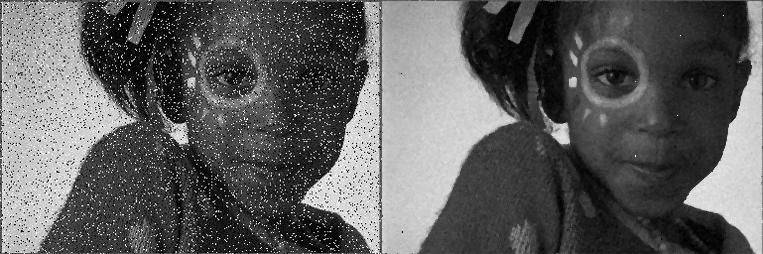

```python
#displaying the results
median_filtered_img3 = median(img,3)
horizontal_show([img,median_filtered_img3],"Original image vs 3x3 Median Filtered image")
```

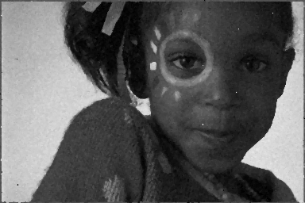

```python
#take a look at the output of the opencv in-built median filter
img_median = cv.medianBlur(img, 3)
cv2_imshow(img_median)
```

Therefore in-built version and my version are both the same.

[figure not shown]

```python
#dispalying histograms of each images
hist_1 = cv.calcHist([cameraman],[0],None,[256],[0,256])
hist_2 = cv.calcHist([np.array(median_filtered_img3,dtype=np.uint8)],[0],None,[256],[0,256])


fig = plt.figure(figsize=(10, 7))
fig.add_subplot(2, 3, 4)
plt.title("Original")
plt.plot(hist_1)
fig.add_subplot(2, 3, 5)
plt.title("kernal size 5")
plt.plot(hist_2)
```

### Comments

Noise in the image is removed and the image is much more enhanced.